# Text Classification in Python

## What's the most positive review in the test set according to this?

```python
len(y_test)
```

```
400
```

```python
# Find the index of the most positive/least negative probability:
## sort the predicted_prob_neg array in acsending order using np.argsort
## returns the index at the 1st position
least_negative_index = np.argsort(predicted_prob_nb_neg)[0]

# Both of these should return the same index
```

```python
least_negative_index
```

```
290
```

```python
predicted_prob_nb[least_negative_index]
```

```
array([1.27249754e-42, 1.00000000e+00])
```

```python
y_test.iloc[least_negative_index]
```

```
1
```

```python
test_data.iloc[least_negative_index]
```

```
'i know that " funnest " isn\'t a word . \n " fun " is a noun , and therefore cannot be conjugated like an adjective . \nbut that\'s the word that came to me right after viewing " chicken run . " \nno wonder : this is the kind of movie that reduces you to childish expressions , like " that was the f…
```

## What is the most negative review in the test set according to this?

```python
# Find the index of the most negative/least positive probability:
least_positive_index  = np.argsort(predicted_prob_nb_pos)[0]
least_positive_index
```

```
48
```

```python
predicted_prob_nb[least_positive_index]
```

```
array([1.00000000e+00, 4.85161314e-39])
```

```python
y_test.iloc[least_positive_index]
```

```
0
```

```python
test_data.iloc[least_positive_index]
```

```
'it rocks-actually , lots of rocks fly at us or from us , in slow or fast motion , at several points in the film . \nthey seem like dangerous rocks because they kind of twirl through the air instead of just propelling forward , and when they land-once in a while , when we need a break from the space…
```

More words means more votes, so longer documents are more clearly positive or negative. It also would underplay a review that read in it's entirety ``terrible,'' even though the review is 100% clear in its sentiment.

## What is it most confused about?

```python
# The index of the probability that is closest to 0.5 for the "positive" class.
most_confused_index = np.argsort(np.abs(predicted_prob_nb_neg - 0.5))[0]
```

```python
predicted_prob_nb[most_confused_index]
```

```
array([0.52331012, 0.47668988])
```

```python
y_test.iloc[most_confused_index]
```

```
1
```

```python
test_data.iloc[most_confused_index] ##
```

```
"review- peter jackson's the frighteners has received some notice for setting the record for most computer effects ever in a movie , and still coming in at the extremely cheap $30 million price tag . \nbut for those who were dismayed by this year's blockbusters like twister and independence day , th…
```

```python
clearly_wrong = np.argsort(predicted_prob_nb_neg[:50])[0]
```

```python
predicted_prob_nb[clearly_wrong]
```

```
array([3.07634031e-38, 1.00000000e+00])
```

```python
y_test.iloc[clearly_wrong]
```

```
0
```

```python
test_data.iloc[clearly_wrong] ## Yup thats a clear mistake. overfitting?
```

```
'the following review encompasses two versions of dune : \ndune : the theatrical version ( 1984 ) runtime : 137 minutes capsule review : cut down to just over two hours by nervous studio executives , the theatrical version of dune is a spectacular mess and may be incomprehensible to those unfamiliar…
```

# Support Vector Machine

Unlike Naive Bayes, which is a probabilistic classifier, SVM is a discriminative classifier that finds the optimal hyperplane to separate different classes in the feature space. This problem can be formulated as a constrained optimization problem, where we seek to maximize the margin between the support vectors while minimizing the classification error.

**Support vectors:** In our context, these are the movie reviews that lie closest to the decision boundary, i.e., the hyperplane that delineates positive and negative reviews. These support vectors are crucial because they define the position and orientation of the decision boundary. They represent the most informative and influential reviews in terms of distinguishing between positive and negative sentiments.

The SVM algorithm constructs the decision boundary such that it maximizes the margin, or the distance between the hyperplane and the closest support vectors from each class. By doing so, the algorithm aims to achieve the best possible separation between positive and negative reviews.

**Interpretability:** SVMs make use of kernels and Linear kernels result in linear decision boundaries, which are easier to interpret and understand. The decision boundary is a hyperplane in the feature space, and the coefficients associated with each feature indicate the importance of that feature in determining the classification decision. This interpretability can be valuable for understanding which features are most relevant for sentiment analysis in movie reviews.

## SVM Fit:

```python
# Import necessary libraries
from sklearn import datasets
from sklearn.model_selection import train_test_split
from sklearn.svm import SVC
from sklearn.metrics import accuracy_score, classification_report


# train_data, test_data, y_train, y_test
# Initialize the SVM model
classifier_svm = SVC(kernel='linear', C= 0.1, probability=True)  # Use linear kernel. You can also try other kernels like 'rbf', 'poly', etc.

# Fit the model to the training data
classifier_svm.fit(X_train_binary, y_train)
```

```
SVC(C=0.1, kernel='linear', probability=True)
```

## SVM Predictions:

```python
# Predicttions - predict the labels for the test data
predicted_proba_svm = classifier_svm.predict_proba(X_test_binary)
predictions_svm = classifier_svm.predict(X_test_binary)
```

## SVM Evalute:

```python
# Evaluate the model
accuracy_svm = accuracy_score(y_test, predictions_svm)
report_svm = classification_report(y_test, predictions_svm)
print("Accuracy:", accuracy_svm)
print("Summary", report_svm)
```

```
Accuracy: 0.84
Summary               precision    recall  f1-score   support

           0       0.83      0.85      0.84       199
           1       0.85      0.83      0.84       201

    accuracy                           0.84       400
   macro avg       0.84      0.84      0.84       400
weighted avg       0.84      0.84      0.84       400
```

## Let's look inside the model:

Let's look at some interpretatble information about the svm model:

```python
# unique classes
print("Unique classes:", classifier_svm.classes_)

# weight vector or coefficient vector (tells us the weights assigned to each feature)
# larger the weight, larger the importance
print("Weight or coefficient vector:", classifier_svm.coef_.toarray())

# number of support vectors for each class
print("Num of support vectors for each class:", classifier_svm.n_support_)

# tot number of support vectors
num_support = sum(classifier_svm.n_support_)
print(f"Total num of support vectors:, {num_support}, This means our SVM model has identified {num_support} data points from the training set as crucial for defining the decision boundary.")

# index of the support vectors
print("Indices of the support vectors:", classifier_svm.support_)

# Lagrange multiplier.y_i associated with each support vector
# This gets used when calculating the weight vector!
print("Lagrange multiplier associated with each support vector:", classifier_svm.dual_coef_.toarray())
```

```
Unique classes: [0 1]
Weight or coefficient vector: [[ 0.0075401  -0.00048252 -0.00550084 ...  0.          0.00062448
   0.        ]]
Num of support vectors for each class: [581 578]
Total num of support vectors:, 1159, This means our SVM model has identified 1159 data points from the training set as crucial for defining the decision boundary.
Indices of the support vectors: [   1    2    3 ... 1595 1598 1599]
Lagrange multiplier associated with each support vector: [[-0.01132617 -0.00020885 -0.00337526 ...  0.004575    0.00079988
   0.00158499]]
```

### Some math:

The decision function is: $f(x) = \mathbf{w} \cdot \mathbf{x} + b$

- If f(x) is positive, the SVM predicts the positive class.
- If f(x) is negative, the SVM predicts the negative class.

The weight vector $(\mathbf{w})$ in the above equation is directly related to the coefficients returned by `.coef_` attribute

**Interpretation:**

$(\mathbf{w})$ act as weights that determine the importance of each feature in the decision-making process. In the above case, each token is a feature and we are weighting the impotance of each token.

*Analogy with Linear Regression:* In linear regression, the coefficients that multiply the input features are often referred to as weights. These weights determine the contribution of each feature to the predicted output. Similarly, in SVMs, $(\mathbf{w})$ determines the orientation of the decision boundary in the feature space, and its components (or the individual elements or values that make up the vector) can be seen as weights assigned to each feature.

**Also note that:**

$\mathbf{w}$ can be expressed as: $\mathbf{w} = \sum_{i=1}^{n} \alpha_i y_i \mathbf{x_i} $

Here, $\alpha_i$ represents the Lagrange multiplier associated with the $i$-th support vector, $y_i$ is the corresponding class label, and $\mathbf{x_i}$ is the $i$-th support vector. The coefficients returned by .coef_ are directly related to the Lagrange multipliers ($\alpha_i$) used in the optimization problem, as they are used to compute the weight vector $\mathbf{w}$.

### Let's use stuff returned by Python to prove that $\mathbf{w} = \sum_{i=1}^{n} \alpha_i y_i \mathbf{x_i} $

```python
# dimention of our document term matrix:
X_train_binary.shape
# There are 41991 features
```

```
(1600, 41991)
```

```python
w_direct = classifier_svm.coef_
w_direct.shape # we have 41991 weights corresponding to each feature/token
```

```
(1, 41991)
```

`classifier_svm.dual_coef_` corresponds to the $\alpha_i y_i$ according to the documentation.

`X_train_binary[classifier_svm.support_]` corresponds to $x_i$. It returns the subset of the training data X_train consisting of only the support vectors identified by the SVM modele. We will find the dot protuct of these two to get the weights associated with each feautre.

We can find the dot product between these two values to get the weights. These weights should equal the weights returned by .coef_.

Let's verify the dimensions of the matrices to make sure we can perform multiplication:

```python
X_train_binary[classifier_svm.support_].shape # there are 1159 support vectors and 41991 features
```

```
(1159, 41991)
```

```python
classifier_svm.dual_coef_.shape # There are 1159 alphi_i, one for every support vector
```

```
(1, 1159)
```

```python
w_calc = np.dot(classifier_svm.dual_coef_, X_train_binary[classifier_svm.support_]) # This dot product will be 1 x 41991
```

```python
np.unique((w_direct == w_calc).toarray(), return_counts=True)
```

```
(array([ True]), array([41991]))
```

Yay! That worked. w_direct and w_calc are indeed the same thing. Let's use these weights to look at the important words for the positive and negative class:

## SVM Feature importance:

```python
# Lets sort the coefficients in ascending order
sorted_coefs = np.argsort(classifier_svm.coef_.toarray()[0])
```

```python
# retrieves the top 30 words from the vocabulary list that are most indicative of the postive class
# (according to their associated coefficients in the SVM model.)
print(vocab_list[sorted_coefs][-1:-31:-1])
print(classifier_svm.coef_.toarray()[0][sorted_coefs][-1:-31:-1])
```

```
['others' 'as' 'very' 'pace' 'memorable' 'change' 'overall' 'town'
 'excellent' 'performances' 'enjoy' 'true' 'well' 'perfectly'
 'wonderfully' 'hilarious' 'sometimes' 'american' 'terrific' 'especially'
 'simple' 'back' 'laughs' 'flaws' 'most' 'that' 'many' 'entertaining'
 'great' 'summer']
[0.13532363 0.12340093 0.11500559 0.11357976 0.11082435 0.10790578
 0.10685244 0.10551024 0.10344589 0.10037851 0.09831883 0.09642252
 0.09472701 0.09466765 0.0943991  0.09433532 0.09327348 0.0923903
 0.09225329 0.0896015  0.08888229 0.08853742 0.08787216 0.08728341
 0.08435347 0.08425743 0.08228719 0.08154667 0.08082275 0.07899405]
```

```python
# retrieves the top 30 words from the vocabulary list that are most indicative of the negative class
# (according to their associated coefficients in the SVM model.)
print(vocab_list[sorted_coefs][:30])
print(classifier_svm.coef_.toarray()[0][sorted_coefs][:30])
```

```
['bad' 'worst' 'waste' 'nothing' 'plot' 'have' 'falls' 'script' 'poor'
 'unfortunately' 'lame' 'awful' 'wasted' 'supposed' 'terrible' 'should'
 'ridiculous' 'only' 'mess' 'stupid' 'boring' 'reason' 'potential'
 'pointless' 'neither' 'flat' 'cheap' '2' 'career' 'maybe']
[-0.15303128 -0.15242166 -0.14769221 -0.14370069 -0.13460148 -0.12386702
 -0.122686   -0.11391206 -0.11325014 -0.11103984 -0.11002238 -0.10935591
 -0.1069662  -0.10439135 -0.10412101 -0.10249379 -0.09819262 -0.09687126
 -0.0967286  -0.0943604  -0.09335848 -0.0916916  -0.0863012  -0.08543421
 -0.08509572 -0.08165018 -0.08156772 -0.07970779 -0.07966579 -0.07944191]
```

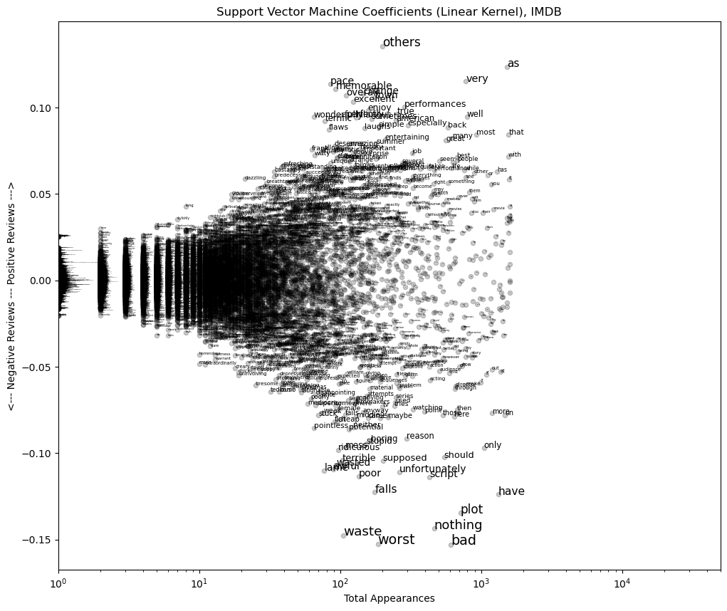

```python
## Lets plot the words based on these coefficients:
import numpy as np
import matplotlib.pyplot as plt

# Assuming dfmat_train contains your training data matrix and beta_svm contains the coefficients

# Compute column sums of dfmat_train
col_sums = np.sum(X_train_binary, axis=0).tolist()[0]
w = classifier_svm.coef_.toarray().tolist()[0]

plt.figure(figsize=(12, 10))

# Plot the coefficients against column sums
plt.scatter(col_sums, w, marker='o', color='black', alpha=0.2, s=20)

# Set plot properties
plt.xscale('log')
plt.xlabel('Total Appearances')
plt.ylabel('<--- Negative Reviews --- Positive Reviews --->')
plt.title('Support Vector Machine Coefficients (Linear Kernel), IMDB')

# Add text annotations
for i, txt in enumerate(vocab_list):
    plt.text(col_sums[i], w[i], txt, fontsize=90*abs(w[i]), color='black')

# Set x-axis limit
plt.xlim(1,50000)

# Show the plot
plt.show()
```

## Grid Search to find C:

In the above code we set $C=.1$ but but this parameter was chose after 'tuning'. I show how to do this below.

$C$ is a hyperparameter that controls the trade-off between maximizing the margin and minimizing the classification error. It represents the penalty imposed on misclassifications during the training process.

When the value of $C$ is small, the SVM algorithm prioritizes maximizing the margin, even if it results in misclassifying some training examples. This approach tends to produce simpler decision boundaries with larger margins, which may generalize better to unseen data. However, too small a value of $C$ can lead to underfitting, where the model may fail to capture the complexities of the data.

On the other hand, when the value of $C$ is large, the algorithm places more emphasis on correctly classifying all training examples, potentially leading to smaller margins and more complex decision boundaries. While this approach may result in better performance on the training data, it also increases the risk of overfitting, where the model memorizes the training data instead of learning general patterns.

```python
from sklearn.model_selection import GridSearchCV
# Define the parameter grid for grid search
# Low to High regularization cost (C)
tune_param = {'C': [0.0001, 0.001, 0.01, 0.1, 0.5, 1, 10, 100, 1000, 10000, 100000]}
print(tune_param)
# Define GridSearchCV with SVM classifier, parameter grid, and 5-fold cross-validation
grid_search_svm = GridSearchCV(SVC(kernel='linear'), tune_param, cv = 5, scoring='accuracy', verbose=3)
grid_search_svm.fit(X_train_binary, y_train)
```

```
{'C': [0.0001, 0.001, 0.01, 0.1, 0.5, 1, 10, 100, 1000, 10000, 100000]}
Fitting 5 folds for each of 11 candidates, totalling 55 fits
[CV 1/5] END ..........................C=0.0001;, score=0.644 total time=   3.1s
[CV 2/5] END ..........................C=0.0001;, score=0.500 total time=   3.0s
[CV 3/5] END ..........................C=0.0001;, score=0.500 total time=   3.0s
[CV 4/5] END ..........................C=0.0001;, score=0.500 total time=   3.0s
[CV 5/5] END ..........................C=0.0001;, score=0.500 total time=   3.0s
[CV 1/5] END ...........................C=0.001;, score=0.831 total time=   2.9s
[CV 2/5] END ...........................C=0.001;, score=0.856 total time=   2.9s
[CV 3/5] END ...........................C=0.001;, score=0.822 total time=   2.8s
[CV 4/5] END ...........................C=0.001;, score=0.850 total time=   2.9s
[CV 5/5] END ...........................C=0.001;, score=0.791 total time=   2.8s
[CV 1/5] END ............................C=0.01;, score=0.831 total time=   2.7s
[CV 2/5] END ............................C=0.01;, score=0.872 total time=   2.8s
[CV 3/5] END ............................C=0.01;, score=0.853 total time=   2.7s
[CV 4/5] END ............................C=0.01;, score=0.869 total time=   2.7s
[CV 5/5] END ............................C=0.01;, score=0.825 total time=   2.7s
[CV 1/5] END .............................C=0.1;, score=0.831 total time=   2.7s
[CV 2/5] END .............................C=0.1;, score=0.872 total time=   2.7s
[CV 3/5] END .............................C=0.1;, score=0.863 total time=   2.7s
[CV 4/5] END .............................C=0.1;, score=0.872 total time=   2.7s
[CV 5/5] END .............................C=0.1;, score=0.828 total time=   2.7s
[CV 1/5] END .............................C=0.5;, score=0.831 total time=   2.7s
[CV 2/5] END .............................C=0.5;, score=0.872 total time=   2.7s
[CV 3/5] END .............................C=0.5;, score=0.863 total time=   2.7s
[CV 4/5] END .............................C=0.5;, score=0.872 total time=   2.7s
[CV 5/5] END .............................C=0.5;, score=0.828 total time=   2.7s
[CV 1/5] END ...............................C=1;, score=0.831 total time=   2.8s
[CV 2/5] END ...............................C=1;, score=0.872 total time=   2.7s
[CV 3/5] END ...............................C=1;, score=0.863 total time=   2.7s
[CV 4/5] END ...............................C=1;, score=0.872 total time=   2.7s
[CV 5/5] END ...............................C=1;, score=0.828 total time=   2.7s
[CV 1/5] END ..............................C=10;, score=0.831 total time=   2.7s
[CV 2/5] END ..............................C=10;, score=0.872 total time=   2.7s
[CV 3/5] END ..............................C=10;, score=0.863 total time=   2.7s
[CV 4/5] END ..............................C=10;, score=0.872 total time=   2.7s
[CV 5/5] END ..............................C=10;, score=0.828 total time=   2.7s
[CV 1/5] END .............................C=100;, score=0.831 total time=   2.8s
[CV 2/5] END .............................C=100;, score=0.872 total time=   2.7s
[CV 3/5] END .............................C=100;, score=0.863 total time=   2.7s
[CV 4/5] END .............................C=100;, score=0.872 total time=   2.8s
[CV 5/5] END .............................C=100;, score=0.828 total time=   2.7s
[CV 1/5] END ............................C=1000;, score=0.831 total time=   2.8s
[CV 2/5] END ............................C=1000;, score=0.872 total time=   2.8s
[CV 3/5] END ............................C=1000;, score=0.863 total time=   2.7s
[CV 4/5] END ............................C=1000;, score=0.872 total time=   2.8s
[CV 5/5] END ............................C=1000;, score=0.828 total time=   2.7s
[CV 1/5] END ...........................C=10000;, score=0.831 total time=   2.8s
[CV 2/5] END ...........................C=10000;, score=0.872 total time=   2.7s
[CV 3/5] END ...........................C=10000;, score=0.863 total time=   2.7s
[CV 4/5] END ...........................C=10000;, score=0.872 total time=   2.8s
[CV 5/5] END ...........................C=10000;, score=0.828 total time=   2.7s
[CV 1/5] END ..........................C=100000;, score=0.831 total time=   2.8s
[CV 2/5] END ..........................C=100000;, score=0.872 total time=   2.7s
[CV 3/5] END ..........................C=100000;, score=0.863 total time=   2.7s
[CV 4/5] END ..........................C=100000;, score=0.872 total time=   2.8s
[CV 5/5] END ..........................C=100000;, score=0.828 total time=   2.7s
```

```
GridSearchCV(cv=5, estimator=SVC(kernel='linear'),
             param_grid={'C': [0.0001, 0.001, 0.01, 0.1, 0.5, 1, 10, 100, 1000,
                               10000, 100000]},
             scoring='accuracy', verbose=3)
```

```python
# Print the best hyperparameters
# We used the best C above
print("Best hyperparameters:", grid_search_svm.best_params_)

# Print the best cross-validation score
print("Best cross-validation score:", grid_search_svm.best_score_)
```

```
Best hyperparameters: {'C': 0.1}
Best cross-validation score: 0.853125
```

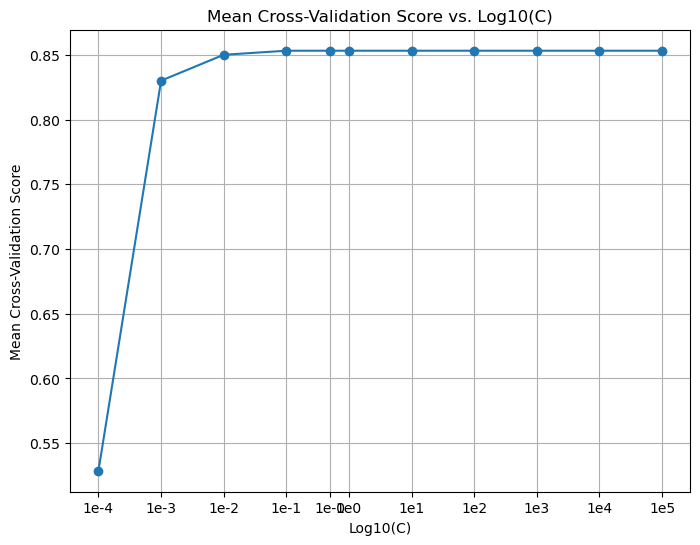

```python
# Extract mean cross-validation scores and corresponding values of C
mean_scores = grid_search_svm.cv_results_['mean_test_score']
C_values = tune_param['C']

# Plot the graph
plt.figure(figsize=(8, 6))
plt.plot(np.log10(C_values), mean_scores, marker='o', linestyle='-')
plt.title('Mean Cross-Validation Score vs. Log10(C)')
plt.xlabel('Log10(C)')
plt.ylabel('Mean Cross-Validation Score')
plt.grid(True)
plt.xticks(np.log10(C_values), [f"1e{x:.0f}" for x in np.log10(C_values)])
plt.show()
```

```python
# Predict using the best estimator found by grid search
y_pred_svm_grid = grid_search_svm.best_estimator_.predict(X_test_dtm)

# Calculate and print the accuracy of the best estimator on the testing data
accuracy_svm_grid = accuracy_score(y_test, y_pred_svm_grid)
print("Accuracy:", accuracy_svm_grid)
```

```
Accuracy: 0.84
```